```python
%pylab inline
from sympy import *
from IPython.display import Image
init_printing(use_latex="mathjax")
```

[output not shown]

# Rotazione del subreflettore intorno al fuoco

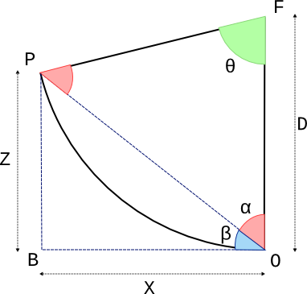

```python
Image("files/rot_sub.png")
```

Sia dato il sistema descritto il figura in cui:

- **O** rappresenta il centro del subriflettore in posizione 0
- **F** rappresenta il fulcro del parboloide
- **D** è la distanza tra il subriflettore e il fuoco nella posizione 0
- $ \theta = \widehat{OFP}$ , angolo di tilt del subriflettore necessario ad inquadrare un feed in vertex
- $|FO| = |FP| = \textbf{D}$

Vogliamo trovare le compensazioni **Z** e **X** da applicare al movimento del subriflettore per mantenerlo centrato sull'asse di fuoco senza introdurre errori di puntamento.

Essendo il triangolo $OFP$ isoscele abbiamo che: $$ \alpha = \frac{\pi - \theta}{2} = \frac{\pi}{2} - \frac{\theta}{2} $$

da cui possiamo ricavare l'ampiezza dell'angolo $\beta$: $$ \beta = \frac{\pi}{2} - \alpha = \frac{\pi}{2} - \frac{\pi}{2} + \frac{\theta}{2} = \frac{\theta}{2} $$

Possiamo quindi calcolare **X** e **Z** sapendo che: $$ |PO| = 2 *(D* \sin{\frac{\theta}{2}}) $$ E sfruttando il fatto che $PBO$ è rettangolo in $B$: $$ X = |PO| *\cos{\beta} = 2* D *\sin{\frac{\theta}{2}}* \cos{\frac{\theta}{2}} = D *\sin{\theta} $$ $$ Z = |PO|* \sin{\beta} = 2 *D* \sin{\frac{\theta}{2}} *\sin{\frac{\theta}{2}} = 2* D * (\sin{\frac{\theta}{2}})^2$$

```python
d, t, z, x = symbols("D theta z x")
z = 2 * d * (sin(t/2)**2)
x = d * sin(t)
```

Sapendo che $ D = 310.7mm $ calcolato geometricamente per il subreflettore possiamo calcolare il variare di **X** e **Z** al variare dell'angolo in vertex

```python
xaxis = linspace(0, radians(8), 1000)
xaxis_labels = linspace(0, 8, 1000)
z_at_fixed_d = 2 * 310.7 * np.sin(xaxis/2)**2
x_at_fixed_d = 310.7 * np.sin(xaxis)
#z_at_fixed_d = array([N(z.subs(D, 310.7).subs(t, _theta)) for _theta in xaxis])
#x_at_fixed_d = array([N(x.subs(D, 310.7).subs(t, _theta)) for _theta in xaxis])
```

Dai plot seguenti vediamo come nella posizione 0 del sureflettore una rotazione di un angolo $\theta$ attorno al fuoco rappresenti una piccola correzione in Z e una più consistente correzione in X

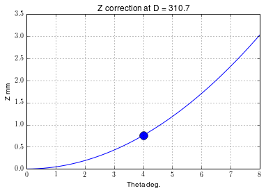

```python
pylab.title("Z correction at D = 310.7")
pylab.xlabel("Theta deg.")
pylab.ylabel("Z mm")
pylab.grid(True)
pylab.plot(xaxis_labels, z_at_fixed_d, 'b-',
           xaxis_labels[500], z_at_fixed_d[500], 'bo',
           markersize = 12)
```

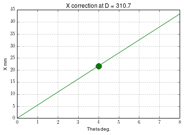

```python
pylab.title("X correction at D = 310.7")
pylab.xlabel("Theta deg.")
pylab.ylabel("X mm")
pylab.grid(True)
pylab.plot(xaxis_labels, x_at_fixed_d, 'g-',
           xaxis_labels[500], x_at_fixed_d[500], 'go',
           markersize = 12)
```

Presupponiamo ora di inquadrare un ricevitore con un angolo di $\theta = 4^{\circ}$ e di voler effettuare un focheggiamento muovendo il subreflettore verso il ricevitore di una quantità che facciamo variare tra 0 e 18cm, calcolati come $ 3\lambda @ 5 GHz$ . Anche in questo caso possiamo controllare il variare delle correzioni applicate in **Z** e **X** al variare della distanza del subreflettore dal fuoco.

```python
xaxis = linspace(0, 180, 1000)
z_at_fixed_t = array([N(z.subs(t, radians(4)).subs(D, _d)) for _d in xaxis])
x_at_fixed_t = array([N(x.subs(t, radians(4)).subs(D, _d)) for _d in xaxis])
```

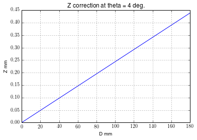

```python
pylab.title("Z correction at theta = 4 deg.")
pylab.xlabel("D mm")
pylab.ylabel("Z mm")
pylab.grid(True)
pylab.plot(xaxis, z_at_fixed_t, 'b-')
```

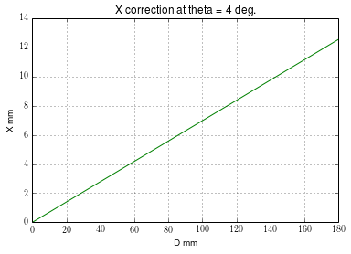

```python
pylab.title("X correction at theta = 4 deg.")
pylab.xlabel("D mm")
pylab.ylabel("X mm")
pylab.grid(True)
pylab.plot(xaxis, x_at_fixed_t, 'g-')
```

# Tilt del subreflettore

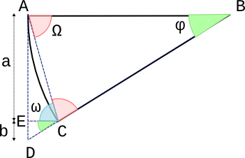

```python
Image("files/tilt_sub2.png")
```

Sia dato il sistema in figura in cui:

**NOTA**: *Per semplicità consideriamo il caso di rotazione sull'asse X applicando un angolo $\theta_y$ che si riflette sul solo movimento di due attuatori. In questo caso sto solo cercando di quantificare un possibile errore, in realtà B si dovrebbe muovere verso l'alto mentre A verso il basso, in questo caso direi che quello che ci interessa è la differenza tra i due.*

Ragionando sui triangoli e sfruttando il fatto che $|AB| = |BC|$ possiamo desumere che:

- $\omega = \Omega$ perchè alterni-interni $$ \Omega = \omega = \frac{\pi - \varphi}{2} = \frac{\pi}{2} - \frac{\varphi}{2} $$ $$ \sin{\Omega} = \sin{\omega} = \cos{\frac{\varphi}{2}} $$ $$ \cos{\Omega} = \cos{\omega} = \sin{\frac{\varphi}{2}} $$

Ragionando a questo punto sui lati otteniamo che:

$$ |AC| = 2*|AB|*\sin(\frac{\varphi}{2}) $$$$ |AE| = |AC| * \sin{\omega} = 2*|AB|*\sin{\frac{\varphi}{2}} * \cos{\frac{\varphi}{2}} = 2*|AB|*\frac{\sin{\varphi}}{2} = |AB|*\sin{\varphi}$$$$ |EC| = |AC| * \cos{\omega} = 2*|AB|*\sin{\frac{\varphi}{2}} * \sin{\frac{\varphi}{2}} = 2*|AB|*(\sin{\frac{\varphi}{2}})^2 = |AB|*(1 - \cos{\varphi}) $$$$ |ED| = |EC| * \tan{\varphi} = |AB|* \tan{\varphi} - |AB|*\cos{\varphi}*\frac{\sin{\varphi}}{\cos{\varphi}} = |AB| * (\tan{\varphi} - \sin{\varphi})$$$$ |AD| = |AB| * \tan{\varphi} $$

Que e ci interessa è che quindi quando noi vogliamo comandare un tilt di $\varphi$ e diamo come posizione comandata $|AD|$ in realtà dovremmo dare un valore di $|AC|$ , per cui: $$ |AD| - |AC| = |AB| *\tan{\varphi} - 2*|AB|*\sin{\frac{\varphi}{2}} = |AB|*(\tan{\varphi} - 2*\sin{\frac{\varphi}{2}}) $$

```python
xaxis = linspace(0, radians(8), 1000)
xaxis_labels = linspace(0, 8, 1000)
error = (2098/2) * (np.tan(xaxis) - 2*np.sin(xaxis/2))
```

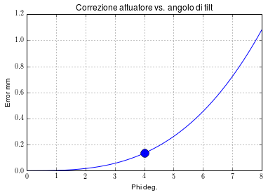

```python
pylab.title("Correzione attuatore vs. angolo di tilt")
pylab.xlabel("Phi deg.")
pylab.ylabel("Error mm")
pylab.grid(True)
pylab.plot(xaxis_labels, error, 'b-',
           xaxis_labels[500], error[500], 'bo',
           markersize = 12)
```